# Reproducible Research - Peer Assessment 1

In this assignment, data acquired from a personal movement monitoring device will be analyzed to compare activity trends throughout the day during weekdays and during weekends.  
This document has 3 main sections:  
- Preparation and Data acquisition  
- Exploratory data analysis  
- Results

The questions asked in the assignment are answered in the **Results** section.

### Preparation and data acquisition

In this section the data and required libraries are loaded and some variables are created.

#### Libraries

```r
library(dplyr)
```

```r
library(reshape2)
library(ggplot2)
library(data.table)
```

#### Data acquisition

```r
#setwd("~/INFOMEDIA/Consultoría/Curso Data Scientist/5 - Reproducible Research/Peer Assessment 1")
activity <- read.csv("activity.csv")
activity$date <- as.Date(activity$date, "%Y-%m-%d")
summary(activity)
```

```
##      steps             date               interval
##  Min.   :  0.00   Min.   :2012-10-01   Min.   :   0.0
##  1st Qu.:  0.00   1st Qu.:2012-10-16   1st Qu.: 588.8
##  Median :  0.00   Median :2012-10-31   Median :1177.5
##  Mean   : 37.38   Mean   :2012-10-31   Mean   :1177.5
##  3rd Qu.: 12.00   3rd Qu.:2012-11-15   3rd Qu.:1766.2
##  Max.   :806.00   Max.   :2012-11-30   Max.   :2355.0
##  NA's   :2304
```

#### Creation of new variables

The following variables will be needed during the assignment and are created here:  
+ Day of week  
+ Weekend indicator

```r
activity <- cbind(activity, weekdays(activity$date), format(activity$date+3, "%U"))
names(activity) <- c("steps","date","interval", "weekday", "weekno")
activity <- cbind(activity, activity$weekday %in% c("Saturday","Sunday"))
names(activity) <- c("steps","date","interval", "weekday", "weekno","is.weekend")

summary(activity)
```

```
##      steps             date               interval           weekday
##  Min.   :  0.00   Min.   :2012-10-01   Min.   :   0.0   Friday   :2592
##  1st Qu.:  0.00   1st Qu.:2012-10-16   1st Qu.: 588.8   Monday   :2592
##  Median :  0.00   Median :2012-10-31   Median :1177.5   Saturday :2304
##  Mean   : 37.38   Mean   :2012-10-31   Mean   :1177.5   Sunday   :2304
##  3rd Qu.: 12.00   3rd Qu.:2012-11-15   3rd Qu.:1766.2   Thursday :2592
##  Max.   :806.00   Max.   :2012-11-30   Max.   :2355.0   Tuesday  :2592
##  NA's   :2304                                           Wednesday:2592
##      weekno     is.weekend
##  41     :2016   Mode :logical
##  42     :2016   FALSE:12960
##  43     :2016   TRUE :4608
##  44     :2016   NA's :0
##  45     :2016
##  46     :2016
##  (Other):5472
```

The **activity** data frame has **17568** rows.

### Exploratory Analysis

This section shows some plots of the data to allow further understanding of it.

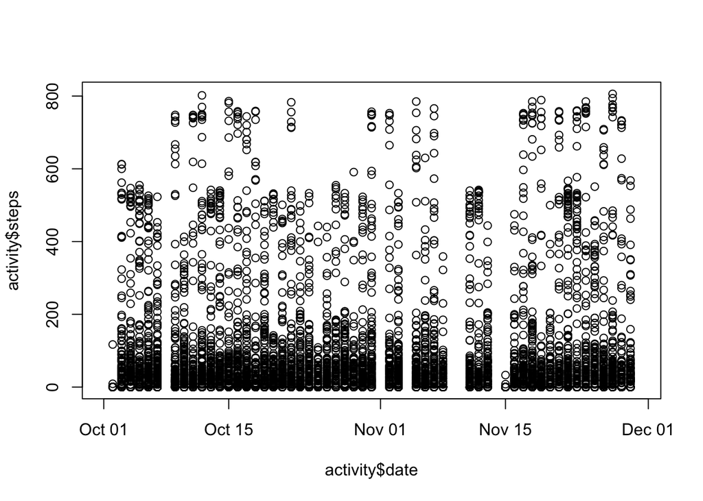

```r
#Sum of steps per day
plot(activity$date,activity$steps)
```

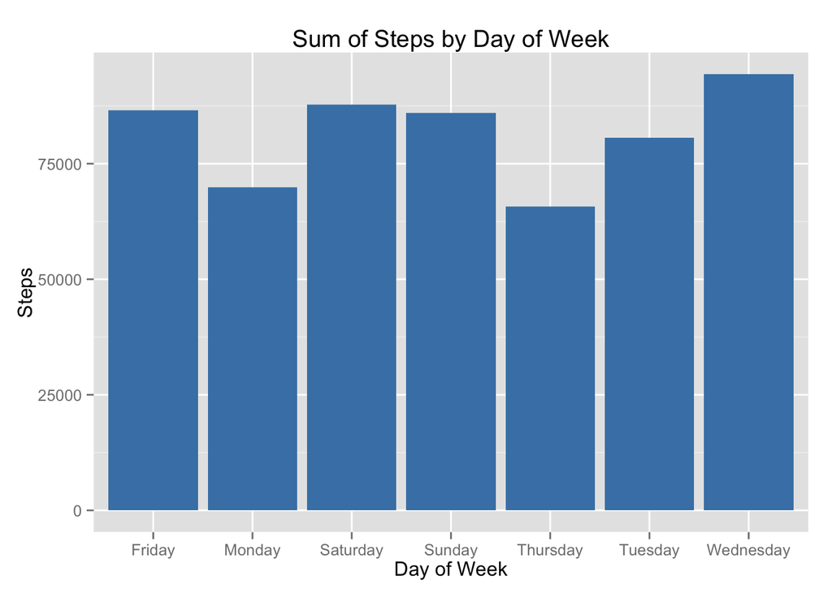

```r
dataMelt <- melt(activity, id=c("date","weekday","weekno","is.weekend","interval"), measure.vars="steps")
sumData <- dcast(dataMelt, date+weekno+weekday+is.weekend+interval~variable, sum)

#Sum of steps per day of week
gSumByDayofWeek <- ggplot(sumData, aes(weekday,steps)) +
        geom_bar(stat="identity", fill="steelblue") +
        labs(title="Sum of Steps by Day of Week") +
        labs(x="Day of Week", y="Steps")
print(gSumByDayofWeek)
```

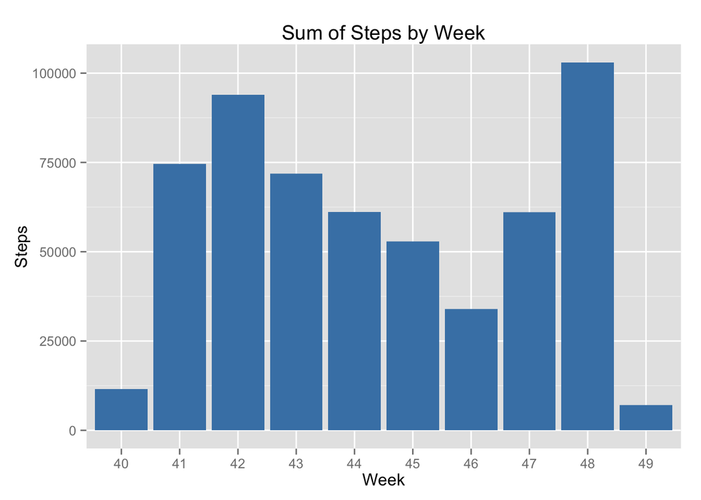

```r
#Sum of steps per week
gSumByWeek <- ggplot(sumData, aes(weekno,steps)) +
        geom_bar(stat="identity", fill="steelblue") +
        labs(title="Sum of Steps by Week") +
        labs(x="Week", y="Steps")
print(gSumByWeek)
```

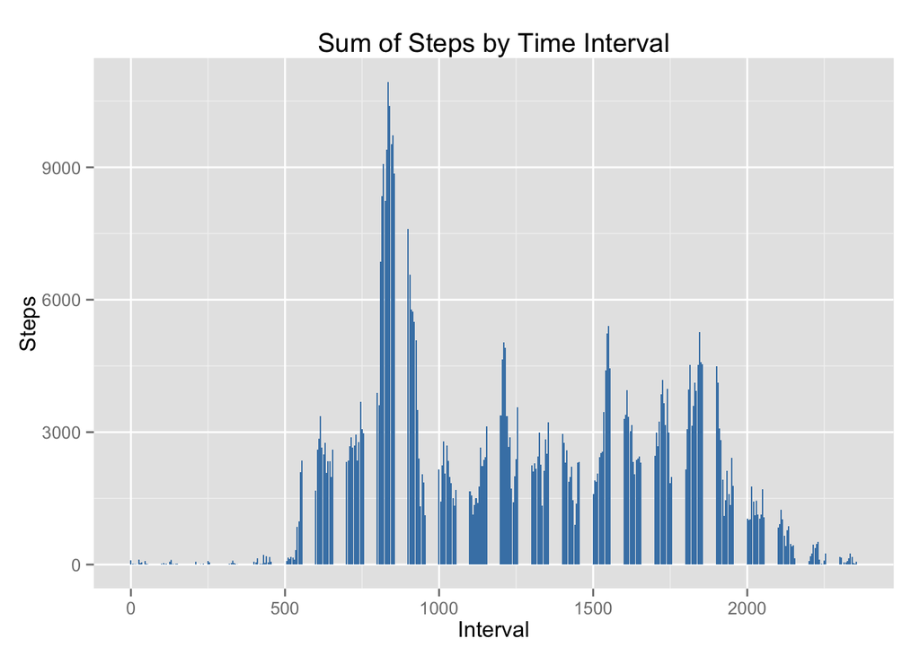

```r
#Sum of steps per Time Interval
gSumByTimeInt <- ggplot(sumData, aes(interval,steps)) +
        geom_bar(stat="identity", fill="steelblue") +
        labs(title="Sum of Steps by Time Interval") +
        labs(x="Interval", y="Steps")
print(gSumByTimeInt)
```

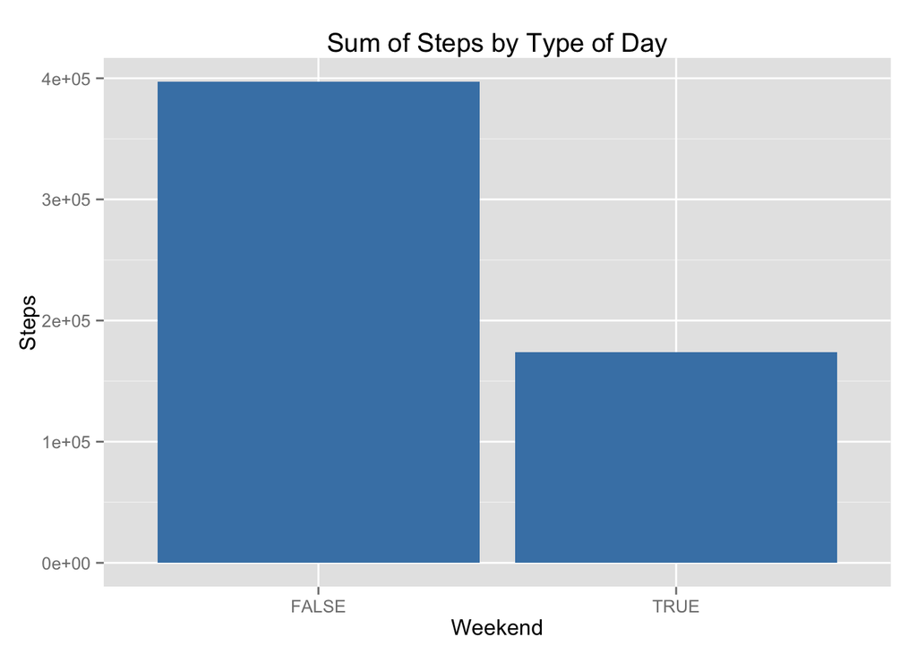

```r
#Sum of steps per type of day (weekday vs weekend)
gSumByDayType <- ggplot(sumData, aes(is.weekend,steps)) +
        geom_bar(stat="identity", fill="steelblue") +
        labs(title="Sum of Steps by Type of Day") +
        labs(x="Weekend", y="Steps")
print(gSumByDayType)
```

### RESULTS

This section shows the answeres to the questions asked in the assignment.

### What is mean total number of steps taken per day?

Total number of steps per day

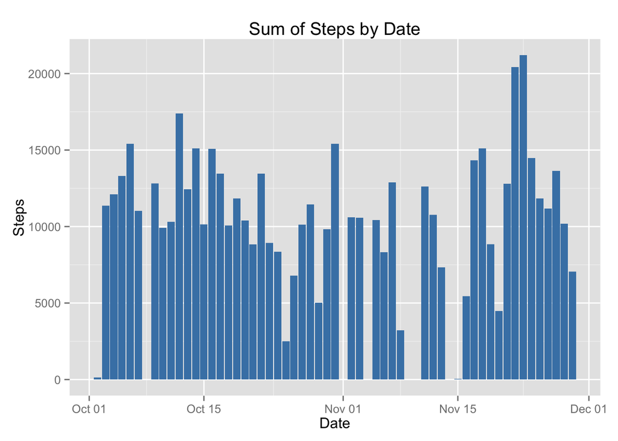

```r
gSumByDay <- ggplot(sumData, aes(date,steps)) +
        geom_bar(stat="identity", fill="steelblue") +
        labs(title="Sum of Steps by Date") +
        labs(x="Date", y="Steps")
print(gSumByDay)
```

Mean & Median of steps per day

```r
dt <- data.table(activity)
dt2 <- dt[,list(sumsteps=sum(steps)),by=date]
results <- c(mean(dt2$sumsteps, na.rm=T), median(dt2$sumsteps, na.rm=T))
names(results) <- c("mean", "median")

results
```

```
##     mean   median
## 10766.19 10765.00
```

### What is the average daily activity pattern?

#### 1. Time series plot of the 5-minute interval and the average number of steps taken, averaged across all days

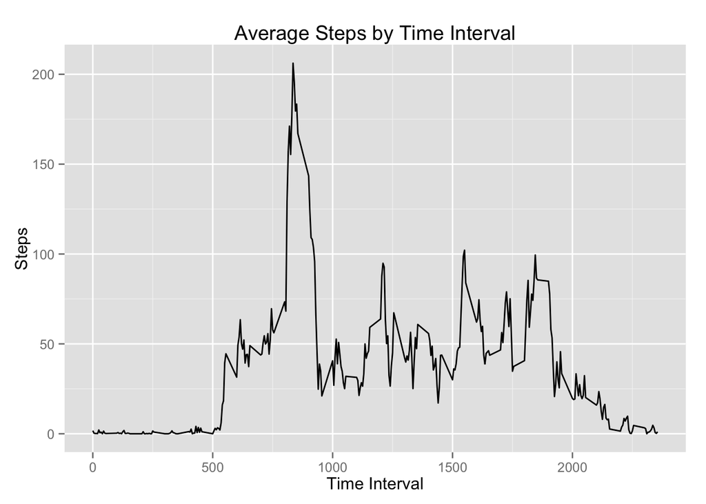

```r
avgData <- dcast(dataMelt, interval~variable, mean, na.rm=T)

gAvgByTimeInt <- ggplot(avgData, aes(interval,steps)) +
        geom_line() +
        labs(title="Average Steps by Time Interval") +
        labs(x="Time Interval", y="Steps")
print(gAvgByTimeInt)
```

#### 2. Which 5-minute interval, on average across all the days in the dataset, contains the maximum number of steps?

The interval with the highest average number of steps is interval **835** with **206.1698113** steps

## Inputting missing values

#### 1. Calculate and report the total number of missing values in the dataset.

The number of rows in the data set with missing values is **2304** out of **17568** which represents **13.11%**.

#### 3. Create a new dataset that is equal to the original dataset but with the missing data filled in

Creating a tidy data set called **tidyactivity**.

```r
#Determining the average number of steps per time interval using only rows with no NA's
cleanactivity <- activity[!is.na(activity$steps),]
cleandataMelt <- melt(cleanactivity, id="interval", measure.vars="steps")
avgSteps <- dcast(cleandataMelt, interval~variable, mean, na.rm=T)

#Merging original data frame with new averages data frame
tidyactivity <- merge(activity, avgSteps, by.x="interval", by.y="interval", sort=F)

#Substituting NA's with corresponding averages
tidyactivity[is.na(tidyactivity$steps.x),2] <- tidyactivity[is.na(tidyactivity$steps.x),7]

#Formatting the new data frame
tidyactivity <- tidyactivity[,c(2,3,1,4,5,6)]
names(tidyactivity) <- c("steps","date","interval", "weekday", "weekno", "is.weekend")
```

The original data frame has 17568 rows and the new one has 17568.  
The original data frame has 2304 NAs and the new one has 0.

#### 4. Make a histogram of the total number of steps taken each day and calculate and report the mean and median total number of steps taken per day.

Total number of steps per day of tidy data

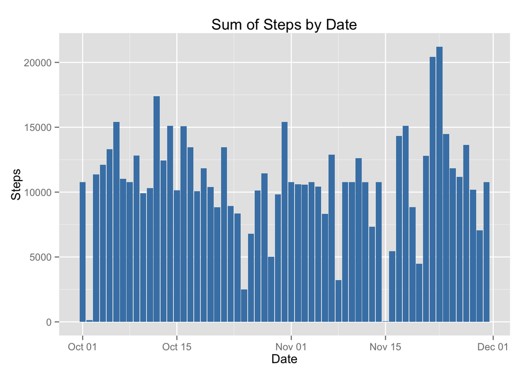

```r
tidydataMelt <- melt(tidyactivity, id=c("date","weekday","weekno","is.weekend","interval"), measure.vars="steps")
sumtidyData <- dcast(tidydataMelt, date+weekno+weekday+is.weekend+interval~variable, sum)

gSumByDaytidy <- ggplot(sumtidyData, aes(date,steps)) +
        geom_bar(stat="identity", fill="steelblue") +
        labs(title="Sum of Steps by Date") +
        labs(x="Date", y="Steps")
print(gSumByDaytidy)
```

Mean & Median of steps per day of tidy data set

```r
dtnew <- data.table(tidyactivity)
dt2new <- dtnew[,list(sumsteps=sum(steps)),by=date]
resultsnew <- c(mean(dt2new$sumsteps), median(dt2new$sumsteps))
names(resultsnew) <- c("mean", "median")

resultsnew
```

```
##     mean   median
## 10766.19 10766.19
```

The **mean** does not change as the values inputed are equal to the mean of the data prior to the substitution of NA’s.

The **median** of the data does increase slightly to align itself with the mean.

## Are there differences in activity patterns between weekdays and weekends?

#### 1. Create a new factor variable in the dataset for “weekday” and “weekend”.

A boolean variable **is.weekend** was created earlier. This variable shows if the date is a weekend (TRUE) or not (FALSE). In this step, the variable will simply be modified to show “Weekend” or “Weekday” accordingly.

```r
tidyactivity$is.weekend[tidyactivity$is.weekend==T] <- "Weekend"
tidyactivity$is.weekend[tidyactivity$is.weekend==F] <- "Weekday"
```

#### 2. Make a panel plot containing a time series plot of the 5-minute interval and the average number of steps taken

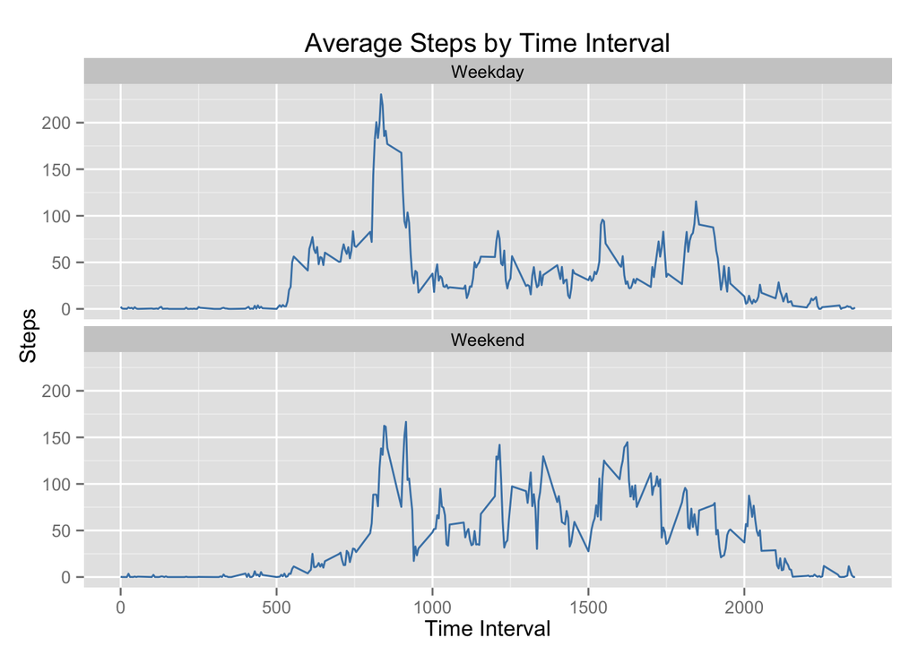

```r
#Generating data set
tidydataMelt <- melt(tidyactivity, id=c("date","weekday","weekno","is.weekend","interval"), measure.vars="steps")
avgtidyData <- dcast(tidydataMelt, interval+is.weekend~variable, mean)

#Plotting
gtidyAvgByTimeInt <- ggplot(avgtidyData, aes(interval,steps)) +
        geom_line(colour="steelblue") +
        labs(title="Average Steps by Time Interval") +
        labs(x="Time Interval", y="Steps") +
        facet_wrap(~is.weekend, nrow=2)
print(gtidyAvgByTimeInt)
```

Wekends seem to have more activity during midday. Let’s investigate further by placing both graphs one on top of the other.

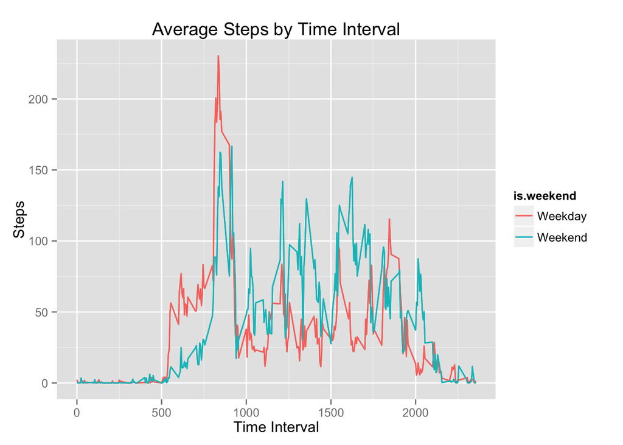

```r
#Plotting Weekend and Weekday one on top of the other
gtidyAvgByTimeInt2 <- ggplot(data = avgtidyData, aes(x = interval,y = steps)) +
        geom_line(aes(color=is.weekend, group=is.weekend)) +
        geom_line(aes(color=is.weekend, group=is.weekend)) +
        labs(title="Average Steps by Time Interval") +
        labs(x="Time Interval", y="Steps")
print(gtidyAvgByTimeInt2)
```

Indeed, there is more activity during the morning on **weekdays** (between time intervals 500 and 800), but activity during the afternoon is higher on **weekends** (between time intervals 1000 and 1800).  
Shortly after the 1800 time interval, activity during **weekdays** spikes over that of **weekends**, but it soon drops back to levels under those of **weekends** for the rest of the day.